# Notes for 2-12

## Highlights

- The Stan model is sensitive to the prior proportion of nulls ($\pi_0$)
- The Stan model with Poisson response has a very poor fit
  - Offsetting biased estimates of several parameters
- The ‘Ribodiff’ model allows different dispersions for RNA and RPF samples in riboseq

### $\pi_0 = 0.8$

I found an error - I was setting $\pi_0 = 0.2$ ($\pi_0$ is the prior proportion of null genes). The true proportion of null genes is $0.8$. Setting $\pi_0 = 0.8$ instead of to an incorrect value improves the performance of the stan models.

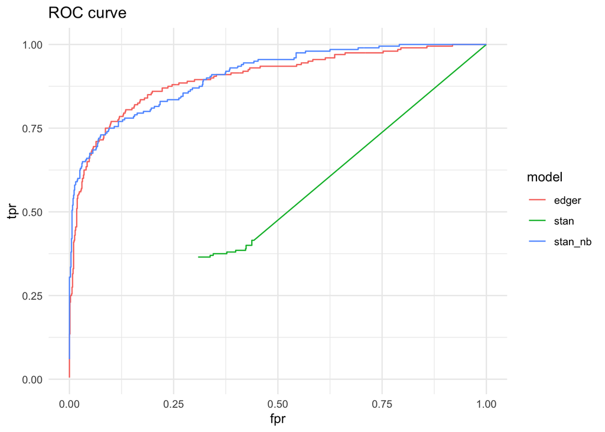

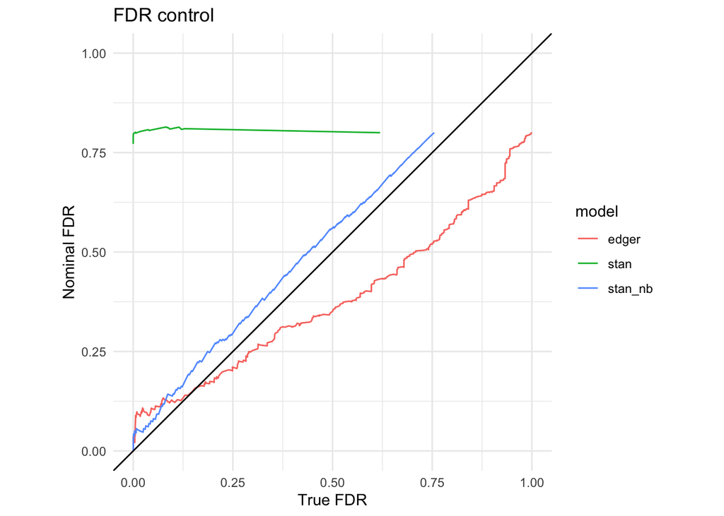

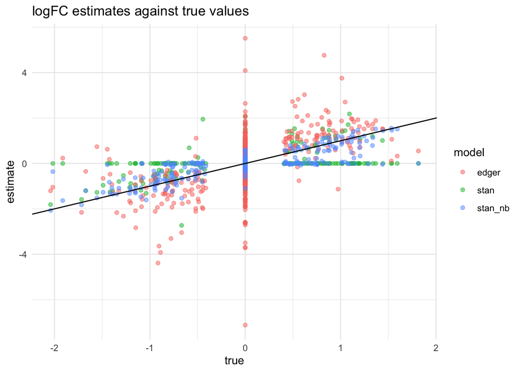

### Poisson Stan fit

The sample normfactors plot isn’t great because of the big difference in y-axis scale, but the Poisson response model is completely missing (overestimating by a large margin) the true value, where the NB response model’s posterior is centered right at the true value.

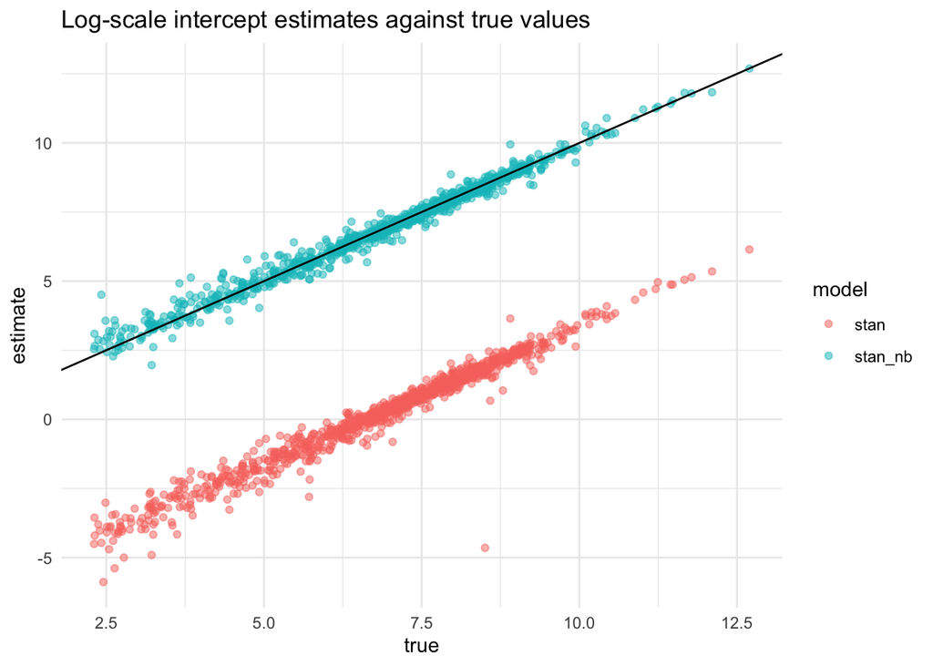

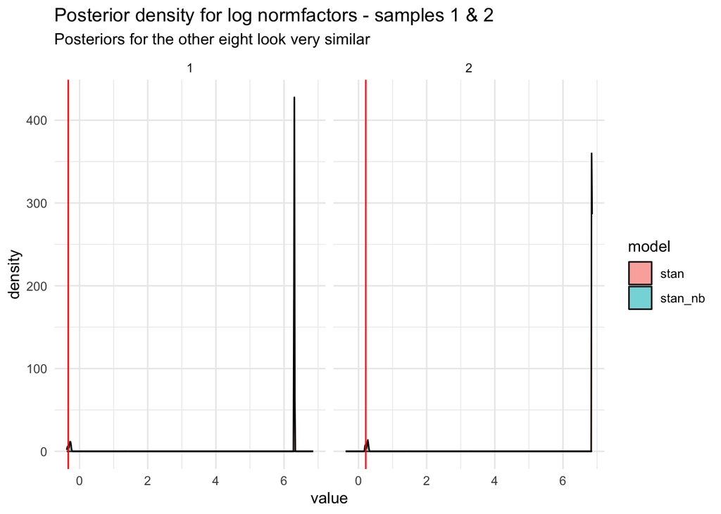

### Ribodiff

- We saw quite poor performance from this method in the ribovi paper (and I think also in one of Ran’s papers?)
- Their model does allow different dispersions for RNA and RPF samples
- Their model does not have any pairing between RNA and RPF from the same biological sample

## Extra

### Adjusting the prior proportion of nulls

I ran the model with a few different settings for the $\pi_0$ prior to test sensitivity.

#### $\pi_0 = 0.9$

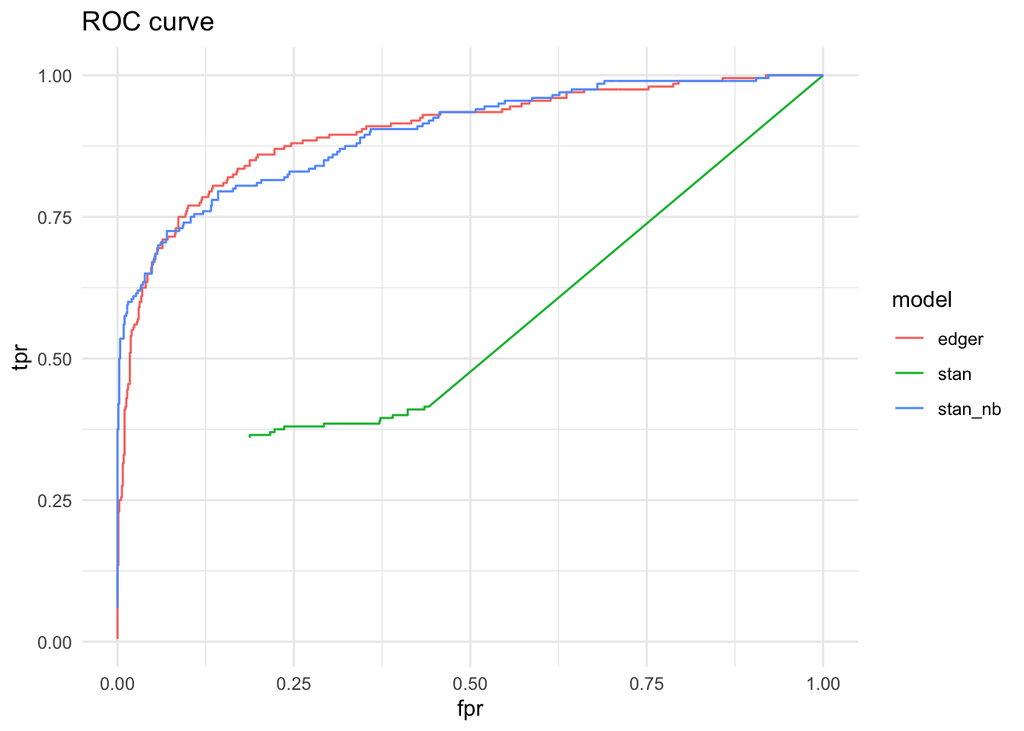

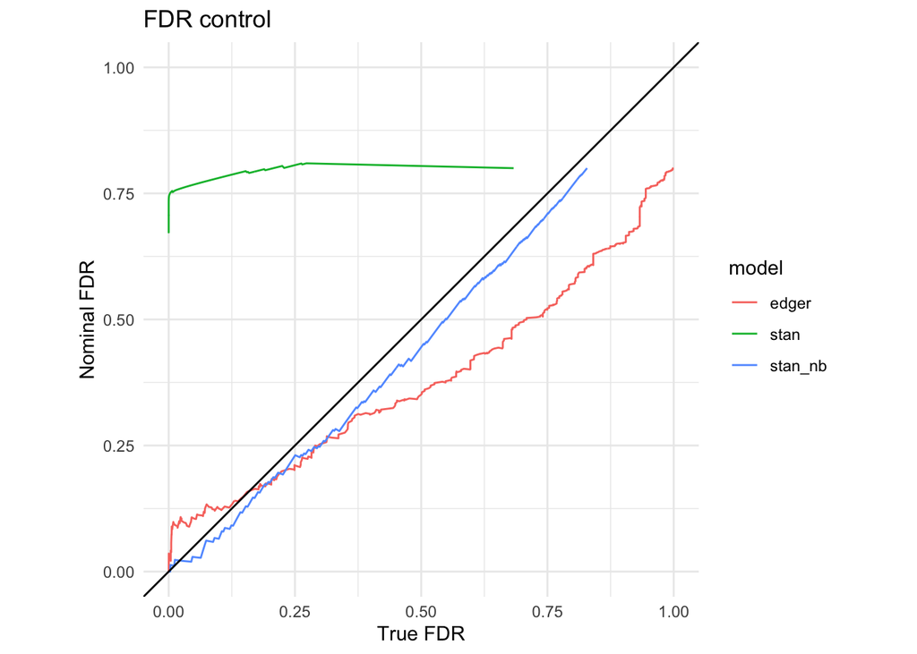

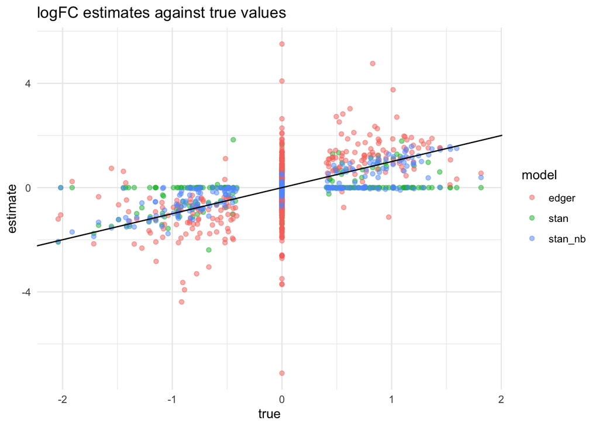

#### $\pi_0 = 0.99$

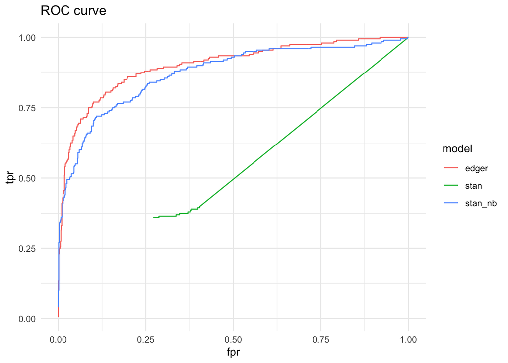

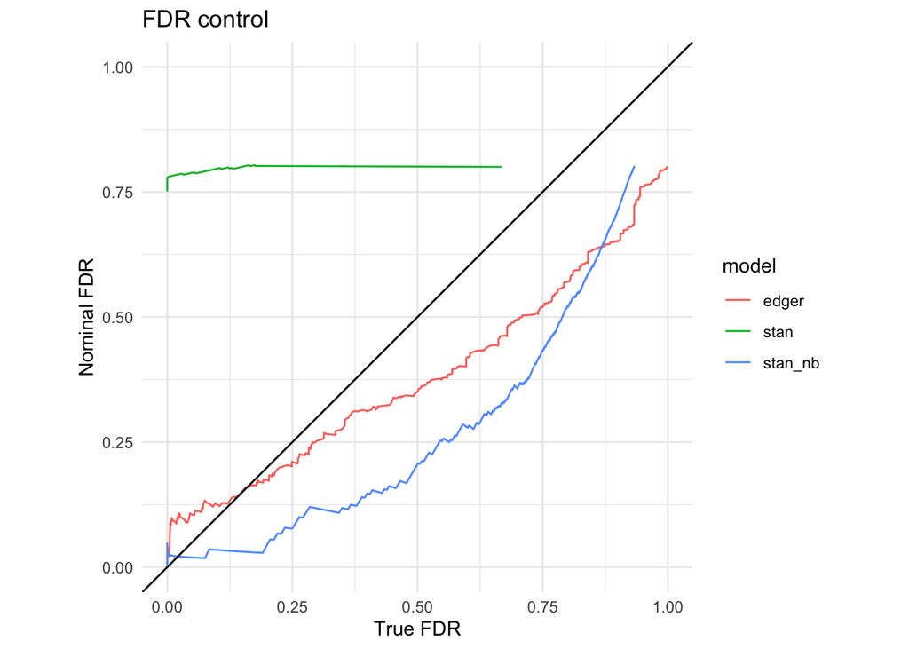

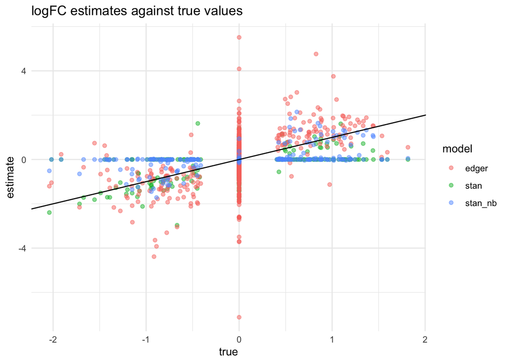

### Simulation description

I replicated a simple simulation setting from [BYN PLOSOne 2020](https://journals.plos.org/plosone/article?id=10.1371/journal.pone.0232271#pone.0232271.ref021) and compared the performance of edgeR and my Stan models on this data set. The setting is just a two-group comparison, with baseline means and dispersions sampled from edgeR estimates produced by a large real data set and FC simulated from 1.5 + exp(1). There are no random effects.